# ImportantSampling

T Xu

```r
N <- 1000 #number of loans.
PosNames <- paste("Loan",1:N,sep="")
beta <- rep(0.3,N) #factor loading
LGD <- rep(0.5,N)
PD <- rep(0.01,N)
EAD <- rep(100,N)

port <- data.frame(PosNames,PD,LGD,EAD,beta,stringsAsFactors = F)
head(port)
```

```
##   PosNames   PD LGD EAD beta
## 1    Loan1 0.01 0.5 100  0.3
## 2    Loan2 0.01 0.5 100  0.3
## 3    Loan3 0.01 0.5 100  0.3
## 4    Loan4 0.01 0.5 100  0.3
## 5    Loan5 0.01 0.5 100  0.3
## 6    Loan6 0.01 0.5 100  0.3
```

To simulate the Portfolio Loss Distribution, single factor model is used here, where the credit risk is determined by systematic factor$Z$, along with idiosyncratic risk $\epsilon$ $V_i = \beta_i Z + \sqrt{1-\beta_i^2} \epsilon_i$ where Z ~ N(0,1), $\epsilon$ ~ N(0,1)

Recall that Expected Loss $\mathbb{E}[Loss] = PD * LGD * EAD$. During the simulation, for each scenario $Loss = LGD * EAD * 1_{Default}$ $1_{Default} = \begin{cases} 1, && \text{Default} \\ 0, && \text{Non-Default} \end{cases}$

In Monte Carlo method, only $1_{Default}$ is simulated, and the loan will be Default if asset value $V$ falls below than Default boundary that $V_i < b_i = N^{-1}(PD_i)$

## Naive Monte Carlo

Systematic factor simulations are drawn from its original distribution $Z$~$N(0,1)$, and Portfolio loss will be the sum of position losses, and all the scenario are equally weighted as $1/M$

```r
###
simMC <- function(port,M){
  N <- nrow(port)
  Z <- (rnorm(M,mean=0))
  LossMC <- matrix(,M,1)
  for (m in 1:M){
    e <- rnorm(N,mean=0,sd=1)
    V <- beta*Z[m] + sqrt(1-beta^2)*e
    default_flag <- V < qnorm(PD)
    LossMC[m] <- sum(default_flag * port$EAD * port$LGD)
  }
  return (data.frame(Loss=LossMC,Weights=1/M))
}
```

## Importance Sampling

Credit risk cares mostely about tail risk, that a portfolio can suffer extemre credit event with less than 1%. Naive Monte Carlo is inefficient as all scenario are equally weighted which requires significant number of simulation to reach a desired level of convegence. Importance Sampling can improve the variance convergence by shifting the weight more on tails during simulation.  
In Importance Sapling Monte Carlo, simulations of Z is drawn from a shifted distribution $N(\mu,1)$, so that mean of the distirubtion can be shifted to desired distribution. For example, $\mu=-3$ is used below representing about 99.86% level of loss.(the lower Z value, the higher probability that loss will occur.)

```r
simIS <- function(port,M,mu){
  N <- nrow(port)
  Z <- (rnorm(M,mean=mu))
  LossIS <- matrix(,M,1)
  for (m in 1:M){
    e <- rnorm(N,mean=0,sd=1)
    V <- beta*Z[m] + sqrt(1-beta^2)*e
    #default_treshold <- (qnorm(PD)-Z*t(beta))/sqrt(1-beta^2)
    default_flag <- V < qnorm(PD)
    LossIS[m] <- sum(default_flag * port$EAD * port$LGD)
  }
  weights <- exp(-mu*Z+mu^2/2)/M
  return (data.frame(Loss=LossIS,Weights=weights))
}
```

```r
library(Hmisc)
```

```r
q = c(0.5,0.9,0.95,0.99,0.999,0.9999)
lossplot <- function(LossRes){
  LossAmt <- LossRes$Loss
  LossWgt <- LossRes$Weights
  Ecdf(LossAmt,weights = LossWgt,datadensity='density',xlim=c(0,10000),ylim=c(0.9,1),q=q)
}

lossquantile <- function(LossRes){
  LossAmt <- LossRes$Loss
  LossWgt <- LossRes$Weights
  return(wtd.quantile(LossAmt,weights=LossWgt,probs=q,normwt=T,type='i/n'))
}

LossBench <- simMC(port,100000) #100k NMC simulation as a benchmark
LossMC <- simMC(port,10000) #10k NMC simulation
LossIS <- simIS(port,10000,-3) #10k IS simulation with shift=-3

Benchmark <- lossquantile(LossBench)
NaiveMC <- lossquantile(LossMC)
ImportanceSampling <- lossquantile(LossIS)
df <- data.frame(Benchmark,NaiveMC,ImportanceSampling)
```

## Comparison

The following table shows the comparison of qifferent quantile using NaiveMC and ImportanceSampling, here the results from 100,000 simulations are used as a benchmark, and use 10,000 simulations for NaiveMC and ImportanceSampling respectively.

```r
t(df)
```

```
##                      50.00%   90.00%   95.00%   99.00%   99.90%   99.99%
## Benchmark          339.4577 1056.744 1391.698 2229.592 3686.364 5700.000
## NaiveMC            346.0616 1049.167 1413.333 2221.429 3600.000 6150.000
## ImportanceSampling 321.7507 1094.257 1427.527 2286.289 3675.972 5285.432
```

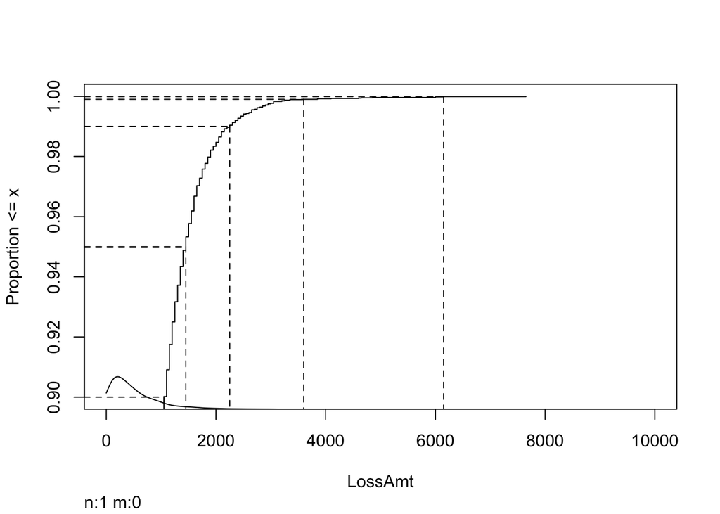

```r
lossplot(LossMC) #most of the simulation is concetrated at small loss.
```

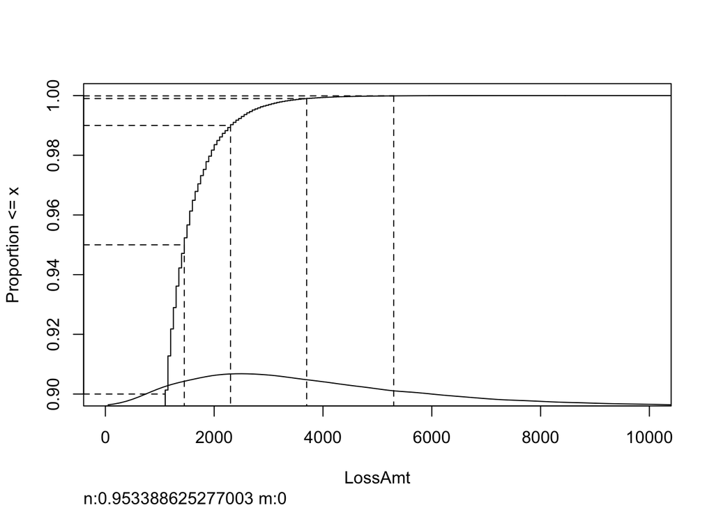

```r
lossplot(LossIS) #median of loss is at large loss, generate more simulation on high loss amount, hence stabler loss measures.
```